# Trabalho final - NT265

Mariane Font Fernandes

17/05/2019

## Introdução

O desenvolvimento de um projeto de pesquisa na pós-graduação requer do estudante a leitura constante de artigos que ampliem seu conhecimento específico, sendo necessário saber a tendência da comunidade científica e o quanto já foi discutido sobre o assunto. A busca por autores bem conceituados na área, assim como artigos de grande impacto para citação, não é fácil em meio a tantos materiais disponíveis. Um modo de conseguir um direcionamento seria através do R e seu pacote “Bibliometrix”, que é capaz de fazer análises quantitativas e estatísticas de publicações e suas citações. Para exemplificar, este roteiro mostra a análise de artigos, que possuem crotonilação (*crotonylation* em inglês) em seu título, seguindo os códigos disponíveis neste pacote.

## Requerimentos:

Para que este roteiro seja executado, é necessário fazer download do:

- [Software R](https://cran.r-project.org/bin/windows/base/);
- [RStudio](https://www.rstudio.com/products/rstudio/download/);
- [Git](https://git-scm.com/downloads);
- [MikTex](https://miktex.org/download);
- Pacote [Rmarkdown](https://cran.r-project.org/web/packages/rmarkdown/index.html), escrevendo no console do RStudio install.packages(“rmarkdown”);
- Pacote [Bibliometrix](https://cran.r-project.org/web/packages/bibliometrix/index.html), escrevendo no console do RStudio install.packages(“bibliometrix”);
- Arquivo Scopus.bib, com dados dos artigos relacionados a crotonilação, adquirido a partir da base de dados [Scopus](https://www.scopus.com/).

## Desenvolvimento:

### 1. Carregando dados e covertendo

Após fazer o download das ferramentas necessárias e criar um diretório no GitHub, carregamos o pacote necessário para análise no RStudio com o comando:

```r
library(bibliometrix)
```

E carregamos o arquivo Scopus.bib, que será atribuído ao vetor D através da função “readFiles”:

```r
D <- readFiles("Scopus.bib")
```

Essa função é capaz de juntar outros arquivos de texto em um mesmo vetor e os converte em UTF-8. Como precisamos dele em data frame para realizar a análise, usaremos a função “convert2df”, indicando o banco de dados utilizado em “dbsource” e o formato do arquivo em “format”. Armazenaremos os dados convertivos em M:

```r
M <- convert2df(D, dbsource="scopus", format="bibtex")
```

```
##
## Converting your scopus collection into a bibliographic dataframe
##
## Articles extracted   36
## Done!
##
##
## Generating affiliation field tag AU_UN from C1:  Done!
```

Em caso de dúvidas quanto as funções, é possível buscar ajuda no RStudio através do comando ?nome_da_função

### 2. Análise bibliométrica

Para fazer a análise descritiva dos dados, utilizaremos a função “biblioAnalysis”, que retorna as principais medidas na bibliometria em um objeto da classe “bibliometrix”:

```r
results <- biblioAnalysis(M, sep=";")
```

### 3. Função *summary* e *plot*

Para resumir os resultados bibliométricos obtidos e conseguir suas principais informações, assim como produção científica anual, principais artigos por número de citações, autores e países mais produtivos, citação total por país, fontes e palavras-chave mais relevantes, usamos a função “summary”:

```r
options(width=100)
S <- summary(object=results, k=10, pause=FALSE)
```

```
##
##
## Main Information about data
##
##  Documents                             36
##  Sources (Journals, Books, etc.)       24
##  Keywords Plus (ID)                    590
##  Author's Keywords (DE)                58
##  Period                                2011 - 2019
##  Average citations per documents       36.19
##
##  Authors                               226
##  Author Appearances                    311
##  Authors of single-authored documents  1
##  Authors of multi-authored documents   225
##  Single-authored documents             1
##
##  Documents per Author                  0.159
##  Authors per Document                  6.28
##  Co-Authors per Documents              8.64
##  Collaboration Index                   6.43
##
##  Document types
##  ARTICLE      30
##  ERRATUM      1
##  LETTER       2
##  NOTE         2
##  REVIEW       1
##
##
## Annual Scientific Production
##
##  Year    Articles
##     2011        1
##     2012        1
##     2015        3
##     2016        5
##     2017        9
##     2018       14
##     2019        3
```

[output cut: 70 more lines]

```
##
##
## Most Relevant Keywords
##
##          Author Keywords (DE)      Articles Keywords-Plus (ID)     Articles
## 1  LYSINE CROTONYLATION                   6     LYSINE                   44
## 2  CROTONYLATION                          3     PROTEIN PROCESSING       36
## 3  HISTONE CROTONYLATION                  3     HISTONE                  34
## 4  POST TRANSLATIONAL MODIFICATION        3     HUMAN                    31
## 5  ACETYLATION                            2     ARTICLE                  22
## 6  CDYL                                   2     HISTONES                 20
## 7  MASS SPECTROMETRY                      2     METABOLISM               20
## 8  PTMS                                   2     NONHUMAN                 17
## 9  SAHA                                   2     POST TRANSLATIONAL       16
## 10 SUPPORT VECTOR MACHINE                 2     PRIORITY JOURNAL         16
```

Para ver alguns gráficos básicos, usamos a função “plot”, que assim como summary, aceita dois argumentos, sendo o “k” o número de linhas de cada tabela e “pause” um valor lógico (TRUE ou FALSE) que define se haverá rolagem de tela ou não.

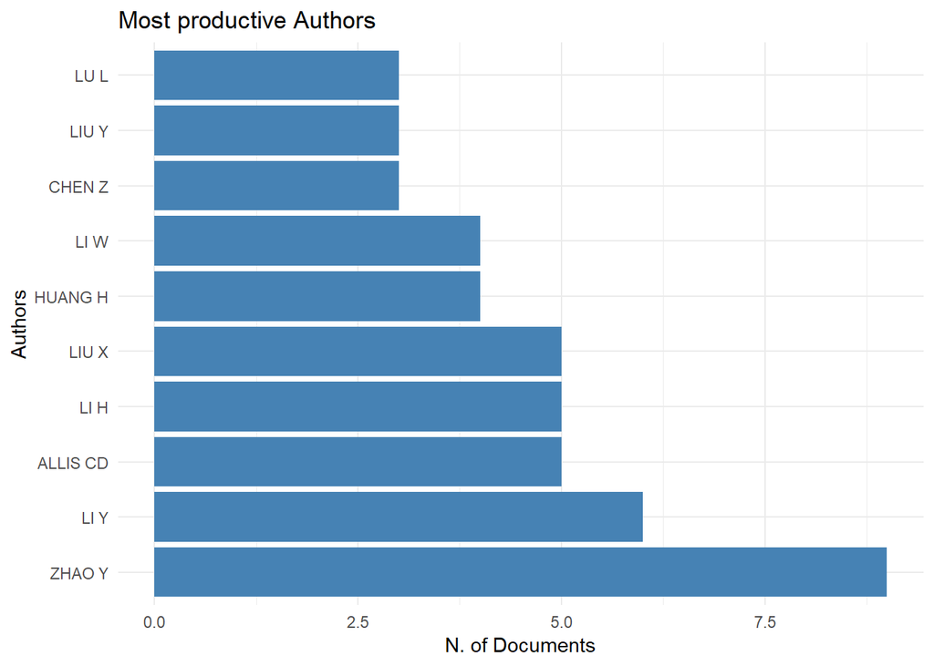

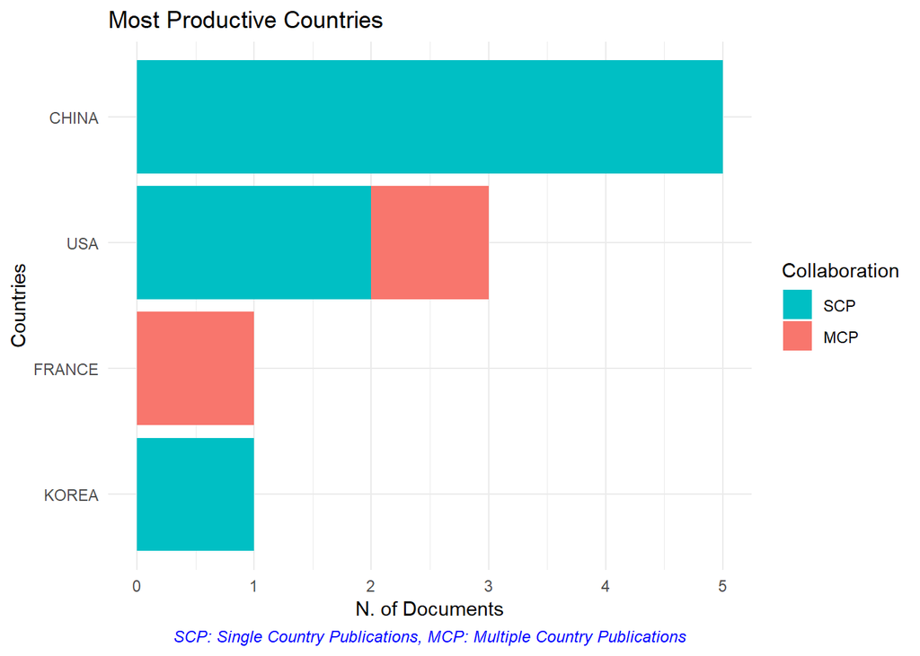

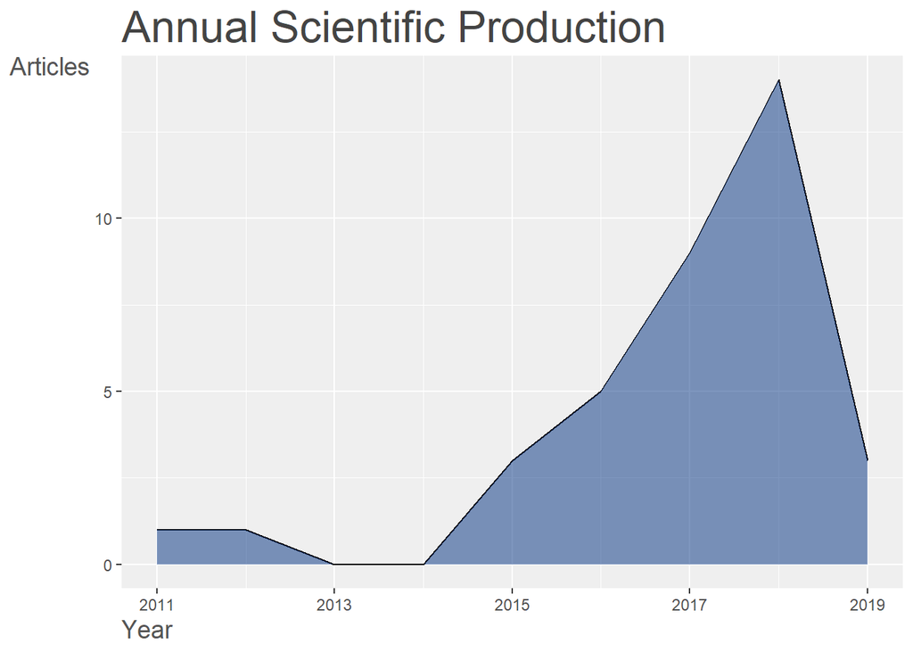

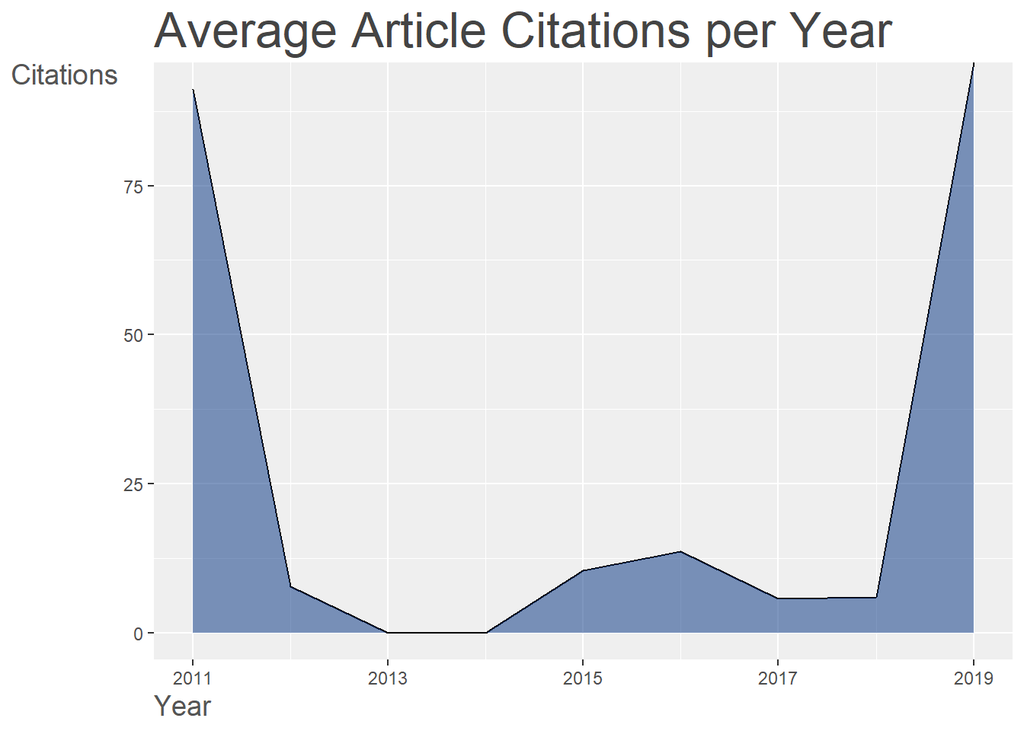

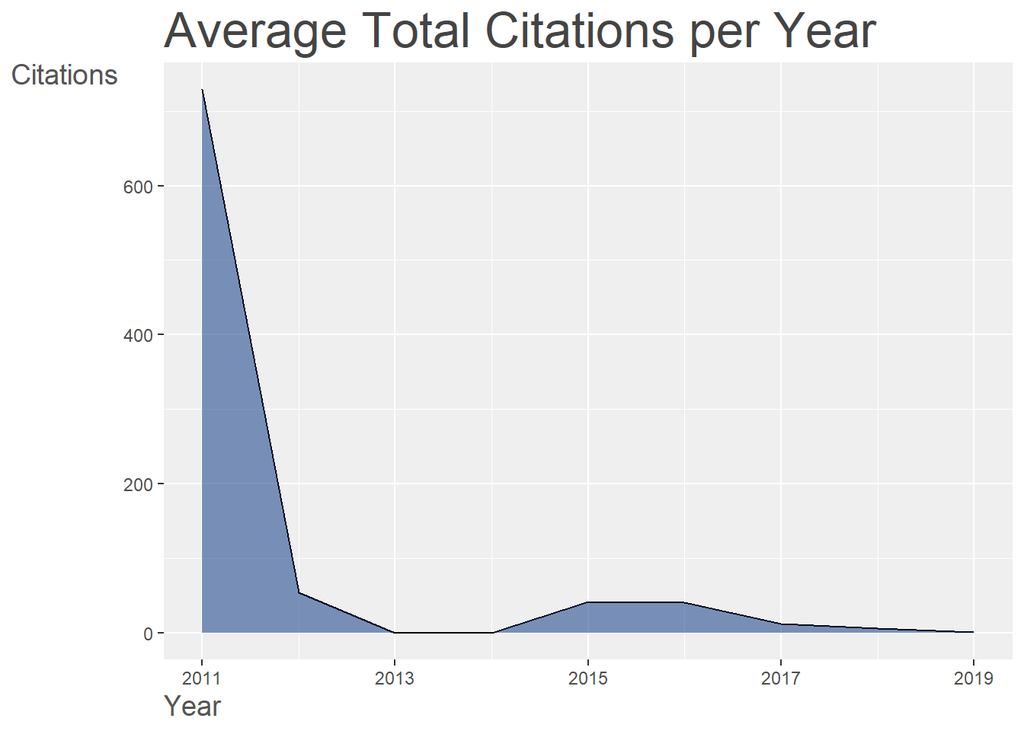

```r
plot(x=results, k=10, pause=FALSE)
```

### 4. Análise de referências citadas

Para ter acesso a uma tabela com a frequência das referências ou principais autores mais citados, utilizamos a função “citations”, sendo necessário indicar qual das duas informações queremos em “field” e qual o separador utilizado em “sep”. Para confirmar qual o separador, utilizamos o seguinte código:

```r
M$CR[1]
```

```
## [1] "SUN, H., KENNEDY, P.J., NESTLER, E.J., EPIGENETICS OF THE DEPRESSED BRAIN: ROLE OF HISTONE ACETYLATION AND METHYLATION (2013) NEUROPSYCHOPHARMACOLOGY, 38, PP. 124-137; LIU, Y., LI, M., FAN, M., SONG, Y., YU, H., ZHI, X., CHROMODOMAIN Y-LIKE PROTEINMEDIATED HISTONE CROTONYLATION REGULATES STR…
```

A figura mostra as referências do primeiro artigo. Nesse caso, o campo separador é “;”.

Para obter os artigos mais citados então, usamos o seguinte código:

```r
CR <- citations(M, field="article", sep=";")
cbind(CR$Cited[1:10])
```

```
##                                                                                                                                                                                                                                      [,1]
## TAN, M., LUO, H., LEE, S., JIN, F., YANG, J.S., MONTELLIER, E., BUCHOU, T., RAJAGOPAL, N., IDENTIFICATION OF 67 HISTONE MARKS AND HISTONE LYSINE CROTONYLATION AS A NEW TYPE OF HISTONE MODIFICATION (2011) CELL, 146, PP. 1016-1028    6
## TAN, M., IDENTIFICATION OF 67 HISTONE MARKS AND HISTONE LYSINE CROTONYLATION AS A NEW TYPE OF HISTONE MODIFICATION (2011) CELL, 146, PP. 1016-1028                                                                                      5
## BERDASCO, M., ESTELLER, M., ABERRANT EPIGENETIC LANDSCAPE IN CANCER: HOW CELLULAR IDENTITY GOES AWRY (2010) DEV. CELL, 19, PP. 698-711                                                                                                  4
## BAO, X., WANG, Y., LI, X., LI, X.M., LIU, Z., YANG, T., WONG, C.F., LI, X.D., IDENTIFICATION OF 'ERASERS' FOR LYSINE CROTONYLATED HISTONE MARKS USING A CHEMICAL PROTEOMICS APPROACH (2014) ELIFE, 3, P. E02999                         3
## KOUZARIDES, T., CHROMATIN MODIFICATIONS AND THEIR FUNCTION (2007) CELL, 128, PP. 693-705                                                                                                                                                3
## LI, Y., SABARI, B.R., PANCHENKO, T., WEN, H., ZHAO, D., GUAN, H., MOLECULAR COUPLING OF HISTONE CROTONYLATION AND ACTIVE TRANSCRIPTION BY AF9 YEATS DOMAIN (2016) MOL CELL, 62, PP. 181-193                                             3
## MONTELLIER, E., ROUSSEAUX, S., ZHAO, Y., KHOCHBIN, S., HISTONE CROTONYLATION SPECIFICALLY MARKS THE HAPLOID MALE GERM CELL GENE EXPRESSION PROGRAM: POST-MEIOTIC MALE-SPECIFIC GENE EXPRESSION (2012) BIOESSAYS, 34, PP. 187-193        3
## SABARI, B.R., TANG, Z., HUANG, H., YONG-GONZALEZ, V., MOLINA, H., KONG, H.E., DAI, L., ZHAO, Y., INTRACELLULAR CROTONYL-COA STIMULATES TRANSCRIPTION THROUGH P300-CATALYZED HISTONE CROTONYLATION (2015) MOL. CELL, 58, PP. 203-215     3
## TAN, M., LUO, H., LEE, S., JIN, F., YANG, J.S., MONTELLIER, E., IDENTIFICATION OF 67 HISTONE MARKS AND HISTONE LYSINE CROTONYLATION AS A NEW TYPE OF HISTONE MODIFICATION (2011) CELL, 146, PP. 1016-1028                               3
## TAVERNA, S.D., LI, H., RUTHENBURG, A.J., ALLIS, C.D., PATEL, D.J., HOW CHROMATIN-BINDING MODULES INTERPRET HISTONE MODIFICATIONS: LESSONS FROM PROFESSIONAL POCKET PICKERS (2007) NAT. STRUCT. MOL. BIOL., 14, PP. 1025-1040            3
```

Para obter os autores mais citados:

```r
CR <- citations(M, field="author", sep=";")
cbind(CR$Cited[1:10])
```

```
##              [,1]
## ZHAO Y         90
## SABARI B R     54
## CHOU K C       51
## CHEN Y         50
## TAN M          49
## ALLIS C D      45
## XIAO X         44
## MONTELLIER E   42
## HUANG H        39
## DAI L          37
```

Para saber quantas vezes um autor (ou um documento) em uma coleção foi citado por outros autores na mesma coleção, utilizamos a função “localCitations”:

```r
CR <- localCitations(M, sep=";")
```

```
## Articles analysed   29
```

```r
CR$Authors[1:10,]
```

|  | Author | LocalCitations |
| --- | --- | --- |
| 197 | ZHAO Y | 83 |
| 1 | ALLIS CD | 49 |
| 53 | HUANG H | 37 |
| 113 | ROEDER RG | 36 |
| 117 | SABARI BR | 36 |
| 143 | TANG Z | 36 |
| 81 | LI Y | 34 |
| 67 | KHOCHBIN S | 33 |
| 101 | MONTELLIER E | 33 |
| 114 | ROUSSEAUX S | 33 |

```r
CR$Papers[1:10,]
```

|  | Paper | DOI | Year | LCS | GCS |
| --- | --- | --- | --- | --- | --- |
| 1 | TAN M, 2011, CELL | 10.1016/J.CELL.2011.08.008 | 2011 | 28 | 729 |
| 3 | SABARI BR, 2015, MOL CELL-a | 10.1016/J.MOLCEL.2015.02.029 | 2015 | 21 | 121 |
| 9 | LI Y, 2016, MOL CELL | 10.1016/J.MOLCEL.2016.03.028 | 2016 | 15 | 71 |
| 16 | WEI W, 2017, CELL RES | 10.1038/CR.2017.68 | 2017 | 10 | 21 |
| 8 | ZHAO D, 2016, CELL RES | 10.1038/CR.2016.49 | 2016 | 8 | 33 |
| 17 | WEI W, 2017, J PROTEOME RES | 10.1021/ACS.JPROTEOME.7B00012 | 2017 | 8 | 16 |
| 6 | RUIZ-ANDRES O, 2016, DNM DIS MODELS MECH | 10.1242/DMM.024455 | 2016 | 7 | 20 |
| 7 | ANDREWS FH, 2016, NAT CHEM BIOL | 10.1038/NCHEMBIO.2065 | 2016 | 7 | 49 |
| 15 | XU W, 2017, CELL RES | 10.1038/CR.2017.60 | 2017 | 7 | 9 |
| 2 | MONTELLIER E, 2012, BIOESSAYS | 10.1002/BIES.201100141 | 2012 | 5 | 54 |

### 5. Ranking de dominância de autores

O ranking de dominância dos autores, feito pela função “dominance”, indica a fração de artigos em que um determinado pesquisador aparece como primeiro autor. Essa função depende do objeto obtido pela biblioAnalysis e “k” indicando o número de autores a considerar na análise.

```r
DF <- dominance(results, k = 10)
DF
```

|  | Author | Dominance Factor | Tot Articles | Single-Authored | Multi-Authored | First-Authored | Rank by Articles | Rank by DF |
| --- | --- | --- | --- | --- | --- | --- | --- | --- |
| 1 | LIU S | 1.0000000 | 2 | 0 | 2 | 2 | 1 | 1 |
| 2 | QIU WR | 1.0000000 | 2 | 0 | 2 | 2 | 1 | 1 |
| 3 | WEI W | 1.0000000 | 2 | 0 | 2 | 2 | 1 | 1 |
| 4 | SABARI BR | 0.6666667 | 3 | 0 | 3 | 2 | 6 | 4 |
| 5 | MONTELLIER E | 0.5000000 | 2 | 0 | 2 | 1 | 1 | 5 |
| 6 | WAN J | 0.5000000 | 2 | 0 | 2 | 1 | 1 | 5 |
| 7 | LI Y | 0.3333333 | 6 | 0 | 6 | 2 | 10 | 7 |
| 8 | LIU Y | 0.3333333 | 3 | 0 | 3 | 1 | 6 | 7 |
| 9 | ZHAO D | 0.3333333 | 3 | 0 | 3 | 1 | 6 | 7 |
| 10 | HUANG H | 0.2500000 | 4 | 0 | 4 | 1 | 9 | 10 |

Neste exemplo, LIU, QIU e WEI dominam seus grupos de pesquisa, por só terem artigos como primeiro autor.

### 6. Índice-h de autores

Para medir o impacto da produtividade e da citação das publicações de um pesquisador, utilizamos a função “Hindex”, calculando o índice H dos autores ou das fontes e suas variantes (índice-g e índice-m) em uma coleção bibliográfica. Essa função tem como argumento um dado bibliográfico, o elemento que queremos analisar em “field” e nomes em “elements”, separando o sobrenome e as iniciais por um espaço em branco para autores.

```r
indices <- Hindex(M, field = "author", elements="LI Y", sep = ";")

# índice de impacto de LI Y:
indices$H
```

| Author | h_index | g_index | m_index | TC | NP | PY_start |
| --- | --- | --- | --- | --- | --- | --- |
| LI Y | 5 | 6 | 1.25 | 151 | 6 | 2016 |

```r
# Citações de LI Y:
indices$CitationList
```

```
## [[1]]
##                          Authors                   Journal Year TotalCitation
## 1 YANG Q;LI Y;APALIYA MT;ZHENG X FRONTIERS IN MICROBIOLOGY 2018             0
## 3        LI Y;ZHAO D;CHEN Z;LI H             TRANSCRIPTION 2017             7
## 2 SUN H;LIU X;LI F;LI W;ZHANG J;        SCIENTIFIC REPORTS 2017             8
## 4 XIONG X;PANCHENKO T;YANG S;ZHA   NATURE CHEMICAL BIOLOGY 2016            32
## 5 ZHAO D;GUAN H;ZHAO S;MI W;WEN              CELL RESEARCH 2016            33
## 6 LI Y;SABARI BR;PANCHENKO T;WEN            MOLECULAR CELL 2016            71
```

Para calcular o índice h dos primeiros 10 autores mais produtivos (nesta coleção) usamos o seguinte código:

```r
authors=gsub(","," ",names(results$Authors)[1:10])

indices <- Hindex(M, field = "author", elements=authors, sep = ";", years = 50)

indices$H
```

| Author | h_index | g_index | m_index | TC | NP | PY_start |
| --- | --- | --- | --- | --- | --- | --- |
| ZHAO Y | 6 | 9 | 0.6666667 | 1041 | 9 | 2011 |
| LI Y | 5 | 6 | 1.2500000 | 151 | 6 | 2016 |
| ALLIS CD | 4 | 5 | 0.8000000 | 257 | 5 | 2015 |
| LI H | 4 | 5 | 1.0000000 | 144 | 5 | 2016 |
| LIU X | 4 | 4 | 1.3333333 | 58 | 4 | 2017 |
| HUANG H | 2 | 4 | 0.4000000 | 193 | 4 | 2015 |
| LI W | 4 | 4 | 1.3333333 | 44 | 4 | 2017 |
| CHEN Z | 3 | 3 | 1.0000000 | 41 | 3 | 2017 |
| LIU Y | 1 | 3 | 0.3333333 | 14 | 3 | 2017 |
| LU L | 2 | 3 | 0.6666667 | 38 | 3 | 2017 |

### 7. Produtividade dos principais autores ao decorrer do tempo

A função “AuthorProdOverTime” calcula e plota a produção dos autores ao longo do tempo, de acordo com o número de publicações e o total de citações por ano. Os argumentos necessários são os dados bibliográficos, o número de autores que você deseja ver em “k” e um valor lógico (TRUE ou FALSE) em “graph” para plotar ou não um gráfico de produção do autor ao longo do tempo.

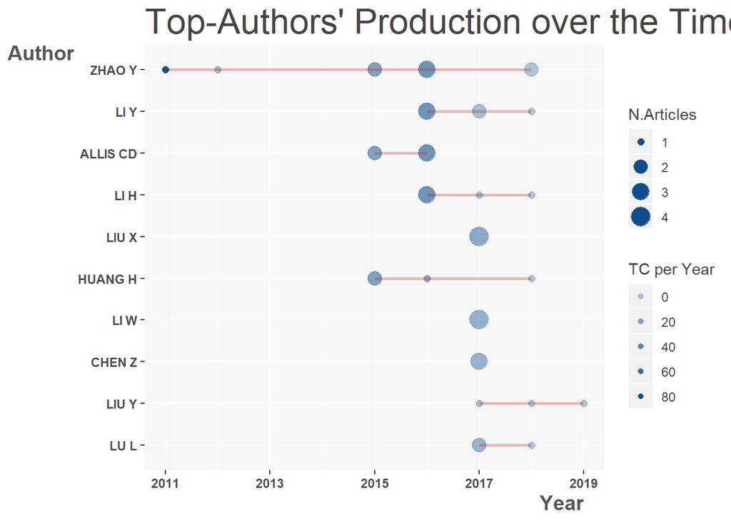

```r
topAU <- authorProdOverTime(M, k=10, graph=TRUE)
```

Para saber a produtividade dos autores por ano:

```r
head(topAU$dfAU)
```

|  | Author | year | freq | TC | TCpY |
| --- | --- | --- | --- | --- | --- |
| 1 | ALLIS CD | 2015 | 2 | 121 | 24.20000 |
| 2 | ALLIS CD | 2016 | 3 | 136 | 34.00000 |
| 3 | CHEN Z | 2017 | 3 | 41 | 13.66667 |
| 4 | HUANG H | 2015 | 2 | 121 | 24.20000 |
| 5 | HUANG H | 2016 | 1 | 71 | 17.75000 |
| 6 | HUANG H | 2018 | 1 | 1 | 0.50000 |

Para saber a lista de artigos desses autores:

```r
head(topAU$dfPapersAU)
```

|  | Author | year | TI | SO | DOI | TC | TCpY |
| --- | --- | --- | --- | --- | --- | --- | --- |
| 2 | ZHAO Y | 2018 | DYNAMICS AND FUNCTIONAL INTERPLAY OF HISTONE LYSINE BUTYRYLATION, CROTONYLATION, AND ACETYLATION IN RICE UNDER STARVATION AND SUBMERGENCE | GENOME BIOLOGY | 10.1186/S13059-018-1533-Y | 0 | 0.00 |
| 3 | ZHAO Y | 2018 | QUANTITATIVE CROTONYLOME ANALYSIS EXPANDS THE ROLES OF P300 IN THE REGULATION OF LYSINE CROTONYLATION PATHWAY | PROTEOMICS | 10.1002/PMIC.201700230 | 1 | 0.50 |
| 4 | ZHAO Y | 2016 | SELECTIVE RECOGNITION OF HISTONE CROTONYLATION BY DOUBLE PHD FINGERS OF MOZ AND DPF2 | NATURE CHEMICAL BIOLOGY | 10.1038/NCHEMBIO.2218 | 32 | 8.00 |
| 5 | ZHAO Y | 2016 | YEATS2 IS A SELECTIVE HISTONE CROTONYLATION READER | CELL RESEARCH | 10.1038/CR.2016.49 | 33 | 8.25 |
| 6 | ZHAO Y | 2016 | MOLECULAR COUPLING OF HISTONE CROTONYLATION AND ACTIVE TRANSCRIPTION BY AF9 YEATS DOMAIN | MOLECULAR CELL | 10.1016/J.MOLCEL.2016.03.028 | 71 | 17.75 |
| 7 | ZHAO Y | 2015 | ERRATUM: INTRACELLULAR CROTONYL-COA STIMULATES TRANSCRIPTION THROUGH P300-CATALYZED HISTONE CROTONYLATION (MOLECULAR CELL (2015) 58(2) (203215)(S1097276515001434)(10.1016/J.MOLCEL.2015.02.029)) | MOLECULAR CELL | 10.1016/J.MOLCEL.2018.01.013 | 0 | 0.00 |

### 8. Estimativa de coeficiente pela lei de Lotka

A função “lotka” verifica a produtividade científica através da lei de Lotka, que descreve a frequência de publicação dos autores como uma lei do inverso do quadrado, onde a quantidade de autores publicando um certo número de artigos é uma razão fixa para a quantidade de autores publicando um único artigo, sendo o coeficiente beta da lei de Lotka igual a 2. É possível avaliar a similaridade desta distribuição empírica, dada pelo coeficiente beta, com a distribuição teórica através de um teste estatístico.

```r
L <- lotka(results)
```

Para saber a distribuição empirica da produtividade do autor:

```r
L$AuthorProd
```

| N.Articles | N.Authors | Freq |
| --- | --- | --- |
| 1 | 174 | 0.769911504 |
| 2 | 36 | 0.159292035 |
| 3 | 9 | 0.039823009 |
| 4 | 2 | 0.008849558 |
| 5 | 3 | 0.013274336 |
| 6 | 1 | 0.004424779 |
| 9 | 1 | 0.004424779 |

Coeficiente Beta estimado:

```r
L$Beta
```

```
## [1] 2.577603
```

Constante:

```r
L$C
```

```
## [1] 0.6907428
```

Qualidade do ajuste:

```r
L$R2
```

```
## [1] 0.9416943
```

p-valor obtido no teste de Kolmogorov-Smirnov:

```r
L$p.value
```

```
## [1] 0.5412431
```

O teste de Kolmogorov-Smirnov fornece um valor de p de 0,54, o que significa que não há diferença significativa entre as distribuições de Lotka observadas e as teóricas.

Podemos comprovar esse resultado comparando as duas distribuições pela função de plotagem:

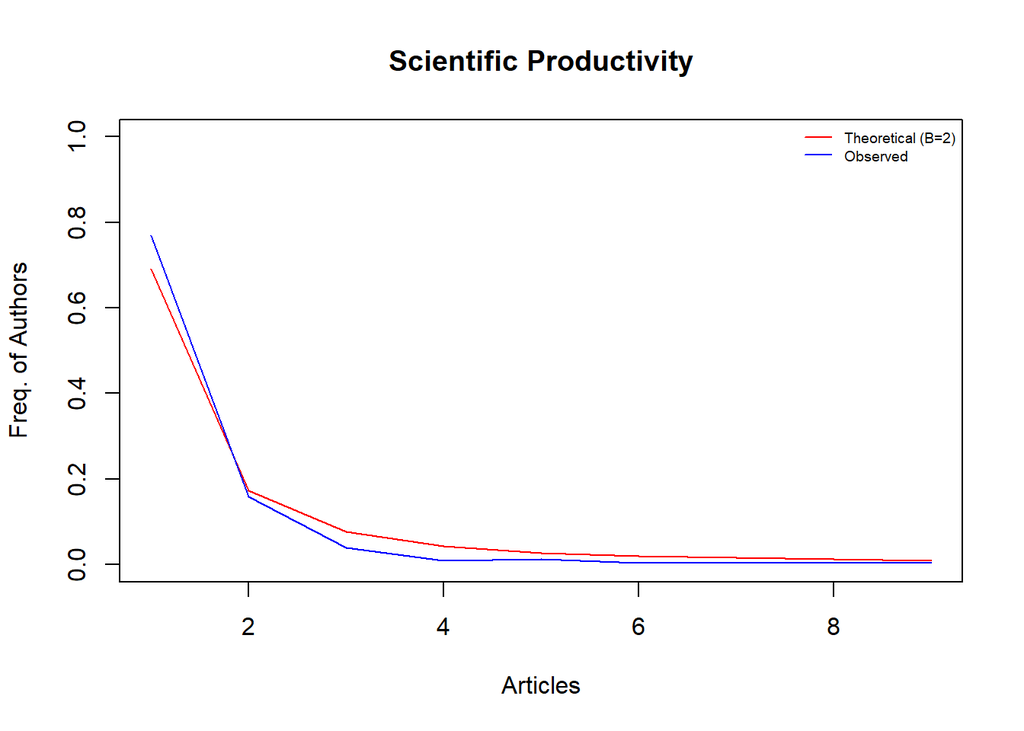

```r
# Distribuição observada:
Observed=L$AuthorProd[,3]

# Distribuição teórica com Beta = 2
Theoretical=10^(log10(L$C)-2*log10(L$AuthorProd[,1]))

plot(L$AuthorProd[,1],Theoretical,type="l",col="red",ylim=c(0, 1), xlab="Articles",ylab="Freq. of Authors",main="Scientific Productivity")
lines(L$AuthorProd[,1],Observed,col="blue")
legend(x="topright",c("Theoretical (B=2)","Observed"),col=c("red","blue"),lty = c(1,1,1),cex=0.6,bty="n")
```

### 9. Matrizes de redes bibliográficas

Os atributos dos artigos estão conectados entre si, gerando redes bipartidas que podem ser representadas como matrizes retangulares (Artigos x Atributos).

Além disso, as referências feitas em publicações científicas gera uma rede adicional, chamada de rede de co-citação ou acoplamento.

Essas redes são analisadas para determinar propriedades significativas do sistema de pesquisa subjacente e verificar a influência de unidades bibliométricas, como acadêmicos e periódicos.

#### a. Redes bipartidas

Para calcular uma rede bipartida selecionando um de seus atributos, utilizamos a função “cocMatrix”.

```r
U <- cocMatrix(M, Field = "SO", sep = ";")
```

Neste caso, relacionamos artigos (linhas) e fontes de publicação (colunas) em uma rede bipartida, usando “SO” em “fields”.

Classificando, em ordem decrescente, podemos ver as fontes de publicação mais relevantes:

```r
sort(Matrix::colSums(U), decreasing = TRUE)[1:5]
```

```
##           SCIENTIFIC REPORTS               MOLECULAR CELL JOURNAL OF PROTEOME RESEARCH                CELL RESEARCH
##                            4                            4                            3                            3
##        BIOLOGICAL PSYCHIATRY
##                            2
```

Outras possibilidades para o campo “fields” incluem “CR” para rede de citações, “AU” para rede de autores, “DE” para rede de palavras-chave do autor, “ID” para rede de mais palavras-chave e “AU_CO” para rede de países dos autores. Neste último caso, precisamos extrair essas informações do atributo de afiliação usando a função “metaTagExtraction”, por não ser um atributo padrão de tabelas de dados bibliográficos.

```r
# Rede de Citações:
X <- cocMatrix(M, Field="CR", sep=". ")
```

```r
# Rede de Autores:
Y <- cocMatrix(M, Field = "AU", sep = ";")
```

```r
# Rede de Palavras-chave do Autor:
V <- cocMatrix(M, Field = "DE", sep = ";")
V
```

```
## 36 x 58 sparse Matrix of class "dgCMatrix"
```

```
##    [[ suppressing 58 column names 'CDYL', 'DENDRITIC SPINE', 'DEPRESSION' ... ]]
```

```
##
## CHAN JC, 2019, BIOL PSYCHIATRY                 . . . . . . . . . . . . . . . . . . . . . . . . . . . . . . . . . . . .
## LIU Y, 2019, BIOL PSYCHIATRY                   1 1 1 1 1 1 . . . . . . . . . . . . . . . . . . . . . . . . . . . . . .
## WAN J, 2019, BIOMED PHARMACOTHER               . . . . . . 1 1 1 . . . . . . . . . . . . . . . . . . . . . . . . . . .
## KELLY RDW, 2018, SCI REP                       . . . . . . . . . . . . . . . . . . . . . . . . . . . . . . . . . . . .
## LIU K, 2018, SCI REP                           . . . . . . . . . . . . . . . . . . . . . . . . . . . . . . . . . . . .
## KWON OK, 2018, SCI REP                         . . . . . . . . . . . . . . . . . . . . . . . . . . . . . . . . . . . .
## FELLOWS R, 2018, NAT COMMUN                    . . . . . . . . . . . . . . . . . . . . . . . . . . . . . . . . . . . .
## LIU S, 2018, MOL CELL PROTEOMICS               . . . . . . . . . . . . . . . . . . . . . . . . . . . . . . . . . . . .
## LU Y, 2018, GENOME BIOL                        . . . . . . . . . . . . . . . . . . . . . . . . . . . . . . . . . . . .
## WU Q, 2018, J PROTEOME RES                     . . . . . . 1 . . 1 1 1 . . . . . . . . . . . . . . . . . . . . . . . .
## YANG Q, 2018, FRONT MICROBIOL                  . . . . . . . . . . . . 1 1 1 1 1 . . . . . . . . . . . . . . . . . . .
## CHEN W, 2018, MEDICINE                         . . . . . . . . . . . . . . . . . 1 1 1 . . . . . . . . . . . . . . . .
## QIU WR, 2018, GENOMICS                         . . . . . . . . . . . . . . . . . 1 . . 1 1 1 1 1 . . . . . . . . . . .
## HUANG H, 2018, PROTEOMICS                      . . . . . . . . . . . . . . . 1 . 1 . . . . . . . 1 1 1 . . . . . . . .
## LIU LJ, 2018, J SHANGHAI JIAOTONG UNIV MED SCI . . . . . . . . . . . . . . . . . 1 . . . . . . . . . . 1 1 1 . . . . .
## BOS J, 2018, J AM CHEM SOC                     . . . . . . . . . . . . . . . . . . . . . . . . . . . . . . . . . . . .
## JIANG G, 2018, J CLIN INVEST                   . . . . . . . . . . . . . . . . . . . . . . . . . . . . . . . . . . . .
## SUN H, 2017, SCI REP                           . . . . . . . . . . . . . . . . . . . . . . . . . . . . . . . . . . . .
## QIU WR, 2017, ARTIF INTELL MED                 . . . . . . . . . . . . . . . . . . . . . . . . 1 . . . . . . 1 1 1 . .
## WU Q, 2017, J PROTEOME RES                     . . . . . . . . . . . 1 . . . . . 1 . . . . . . . . . . . . . . . . 1 1
## JU Z, 2017, J MOL GRAPH MODEL                  . . . . . . 1 . . . . . . . . 1 . . . . . . . . . . . . . . . . . 1 . .
## LIU S, 2017, MOL CELL                          1 . . 1 . . . . . . . . . . . . . . . . . . . . . . . . . . . . . . . .
## XU W, 2017, CELL RES                           . . . . . . . . . . . . . . . . . . . . . . . . . . . . . . . . . . . .
## WEI W, 2017, CELL RES                          . . . . . . . . . . . . . . . . . . . . . . . . . . . . . . . . . . . .
## WEI W, 2017, J PROTEOME RES                    . . . . . . . . . . . . . . . . . 1 . 1 . . . . . . . . . . . . . . . .
## LI Y, 2017, TRANSCRIPTION                      . . . 1 . . . . . . . . . . . . . . . . . . . . . . . . . . . . . . . .
## XIONG X, 2016, NAT CHEM BIOL                   . . . . . . . . . . . . . . . . . . . . . . . . . . . . . . . . . . . .
## RUIZ-ANDRES O, 2016, DNM DIS MODELS MECH       . . . . . . . . . . . . . . . . . . . . . . . . . . . . . . . . . . . .
## ANDREWS FH, 2016, NAT CHEM BIOL                . . . . . . . . . . . . . . . . . . . . . . . . . . . . . . . . . . . .
## ZHAO D, 2016, CELL RES                         . . . . . . . . . . . . . . . . . . . . . . . . . . . . . . . . . . . .
## LI Y, 2016, MOL CELL                           . . . . . . . . . . . . . . . . . . . . . . . . . . . . . . . . . . . .
## SABARI BR, 2015, MOL CELL                      . . . . . . . . . . . . . . . . . . . . . . . . . . . . . . . . . . . .
## SABARI BR, 2015, MOL CELL-a                    . . . . . . . . . . . . . . . . . . . . . . . . . . . . . . . . . . . .
## BAUMANN K, 2015, NAT REV MOL CELL BIOL         . . . . . . . . . . . . . . . . . . . . . . . . . . . . . . . . . . . .
## MONTELLIER E, 2012, BIOESSAYS                  . . . . . . . . . . 1 . . . . . . . . . . . . . . . . . . . . . . . . .
## TAN M, 2011, CELL                              . . . . . . . . . . . . . . . . . . . . . . . . . . . . . . . . . . . .
##
## CHAN JC, 2019, BIOL PSYCHIATRY                 . . . . . . . . . . . . . . . . . . . . . .
## LIU Y, 2019, BIOL PSYCHIATRY                   . . . . . . . . . . . . . . . . . . . . . .
```

[output cut: 19 more lines]

```
## LIU S, 2017, MOL CELL                          . . 1 1 1 1 . . . . . . . . . . . . . . . .
## XU W, 2017, CELL RES                           . . . . . . . . . . . . . . . . . . . . . .
## WEI W, 2017, CELL RES                          . . . . . . . . . . . . . . . . . . . . . .
## WEI W, 2017, J PROTEOME RES                    . . . . . . 1 1 1 . . . . . . . . . . . . .
## LI Y, 2017, TRANSCRIPTION                      . . . . . . . . . 1 1 1 1 . . . . . . . . .
## XIONG X, 2016, NAT CHEM BIOL                   . . . . . . . . . . . . . . . . . . . . . .
## RUIZ-ANDRES O, 2016, DNM DIS MODELS MECH       . . . . . . . . . . . . . 1 1 1 1 1 . . . .
## ANDREWS FH, 2016, NAT CHEM BIOL                . . . . . . . . . . . . . . . . . . . . . .
## ZHAO D, 2016, CELL RES                         . . . . . . . . . . . . . . . . . . . . . .
## LI Y, 2016, MOL CELL                           . . . . . . . . . . . . . . . . . . . . . .
## SABARI BR, 2015, MOL CELL                      . . . . . . . . . . . . . . . . . . . . . .
## SABARI BR, 2015, MOL CELL-a                    . . . . . . . . . . . . . . . . . . . . . .
## BAUMANN K, 2015, NAT REV MOL CELL BIOL         . . . . . . . . . . . . . . . . . . . . . .
## MONTELLIER E, 2012, BIOESSAYS                  . . . . . . . . . . . . . . . . . . 1 1 1 1
## TAN M, 2011, CELL                              . . . . . . . . . . . . . . . . . . . . . .
```

```r
# Rede de mais Palavras-chave:
G <- cocMatrix(M, Field = "ID", sep = ";")
```

```r
# Rede de Países dos Autores:
N <- metaTagExtraction(M, Field="AU_CO", sep=";")
Z <- cocMatrix(M, Field="Au_CO", sep = ";")
```

```
## [1] "Field Au_CO is not a column name of input data frame"
```

Obs: Este último não está funcionando.

Entre outros.

#### b. Acoplamento bibliográfico

Para calcular redes de acoplamentos a partir de determinado dado, como Autores, Fontes e Países, utilizamos a função “biblioNetwork”, que usa um argumento de análise e um argumento de rede.

```r
NetMatrix <- biblioNetwork(M, analysis = "coupling", network = "references", sep = ".  ")
NetMatrix
```

```
## 36 x 36 sparse Matrix of class "dgCMatrix"
```

```
##    [[ suppressing 36 column names 'CHAN JC, 2019, BIOL PSYCHIATRY. 2019', 'LIU Y, 2019, BIOL PSYCHIATRY. 2019', 'WAN J, 2019, BIOMED PHARMACOTHER. 2019' ... ]]
```

```
##
## CHAN JC, 2019, BIOL PSYCHIATRY. 2019                 1 . . . . . . . . . . . . . . . . . . . . . . . . . . . . . . . .
## LIU Y, 2019, BIOL PSYCHIATRY. 2019                   . 1 . . . . . . . . . . . . . . . . . . . . . . . . . . . . . . .
## WAN J, 2019, BIOMED PHARMACOTHER. 2019               . . 1 . . . . . . . . . . . . . . . . . . . . . . . . . . . . . .
## KELLY RDW, 2018, SCI REP. 2018                       . . . 1 . . . . . . . . . . . . . . . . . . . . . . . . . . . . .
## LIU K, 2018, SCI REP. 2018                           . . . . 1 . . . . . . . . . . . . . . . . . . . . . . . . . . . .
## KWON OK, 2018, SCI REP. 2018                         . . . . . 1 . . . . . . . . . . . . . . . . . . . . . . . . . . .
## FELLOWS R, 2018, NAT COMMUN. 2018                    . . . . . . 1 . . . . . . . . . . . . . . . . . . . . . . . . . .
## LIU S, 2018, MOL CELL PROTEOMICS. 2018               . . . . . . . 1 . . . . . . . . . . . . . . . . . . . . . . . . .
## LU Y, 2018, GENOME BIOL. 2018                        . . . . . . . . 1 . . . . . . . . . . . . . . . . . . . . . . . .
## WU Q, 2018, J PROTEOME RES. 2018                     . . . . . . . . . 1 . . . . . . . . . . . . . . . . . . . . . . .
## YANG Q, 2018, FRONT MICROBIOL. 2018                  . . . . . . . . . . 1 . . . . . . . . . . . . . . . . . . . . . .
## CHEN W, 2018, MEDICINE. 2018                         . . . . . . . . . . . 1 . . . . . . . . 1 . . . . . . . . . . . .
## QIU WR, 2018, GENOMICS. 2018                         . . . . . . . . . . . . 1 . . . . . . . . . . . . . . . . . . . .
## HUANG H, 2018, PROTEOMICS. 2018                      . . . . . . . . . . . . . 1 . . . . . . . . . . . . . . . . . . .
## LIU LJ, 2018, J SHANGHAI JIAOTONG UNIV MED SCI. 2018 . . . . . . . . . . . . . . 1 . . . . . . . . . . . . . . . . . .
## BOS J, 2018, J AM CHEM SOC. 2018                     . . . . . . . . . . . . . . . 1 . . . . . . . . . . . . . . . . .
## JIANG G, 2018, J CLIN INVEST. 2018                   . . . . . . . . . . . . . . . . 1 . . . . . . . . . . . . . . . .
## SUN H, 2017, SCI REP. 2017                           . . . . . . . . . . . . . . . . . 1 . . . . . . . 1 . . . . . . .
## QIU WR, 2017, ARTIF INTELL MED. 2017                 . . . . . . . . . . . . . . . . . . 1 . . . . . . . . . . . . . .
## WU Q, 2017, J PROTEOME RES. 2017                     . . . . . . . . . . . . . . . . . . . 1 . . . . . . . . . . . . .
## JU Z, 2017, J MOL GRAPH MODEL. 2017                  . . . . . . . . . . . 1 . . . . . . . . 1 . . . . . . . . . . . .
## LIU S, 2017, MOL CELL. 2017                          . . . . . . . . . . . . . . . . . . . . . 1 . . . . . . . . . . .
## XU W, 2017, CELL RES. 2017                           . . . . . . . . . . . . . . . . . . . . . . 1 . . . . . . 1 . . .
## WEI W, 2017, CELL RES. 2017                          . . . . . . . . . . . . . . . . . . . . . . . 1 . . . . . . . . .
## WEI W, 2017, J PROTEOME RES. 2017                    . . . . . . . . . . . . . . . . . . . . . . . . 1 . . . . . . . .
## LI Y, 2017, TRANSCRIPTION. 2017                      . . . . . . . . . . . . . . . . . 1 . . . . . . . 1 . . . . . . .
## XIONG X, 2016, NAT CHEM BIOL. 2016                   . . . . . . . . . . . . . . . . . . . . . . . . . . 1 . . . . . .
## RUIZ-ANDRES O, 2016, DNM DIS MODELS MECH. 2016       . . . . . . . . . . . . . . . . . . . . . . . . . . . 1 . . . . .
## ANDREWS FH, 2016, NAT CHEM BIOL. 2016                . . . . . . . . . . . . . . . . . . . . . . . . . . . . 1 . . . .
## ZHAO D, 2016, CELL RES. 2016                         . . . . . . . . . . . . . . . . . . . . . . 1 . . . . . . 1 . . .
## LI Y, 2016, MOL CELL. 2016                           . . . . . . . . . . . . . . . . . . . . . . . . . . . . . . 1 . .
## SABARI BR, 2015, MOL CELL. 2015                      . . . . . . . . . . . . . . . . . . . . . . . . . . . . . . . . .
## SABARI BR, 2015, MOL CELL-a. 2015                    . . . . . . . . . . . . . . . . . . . . . . . . . . . . . . . . 1
## BAUMANN K, 2015, NAT REV MOL CELL BIOL. 2015         . . . . . . . . . . . . . . . . . . . . . . . . . . . . . . . . .
## MONTELLIER E, 2012, BIOESSAYS. 2012                  . . . . . . . . . . . . . . . . . . . . . . . . . . . . . . . . .
## TAN M, 2011, CELL. 2011                              . . . . . . . . . . . . . . . . . . . . . . . . . . . . . . . . .
##
## CHAN JC, 2019, BIOL PSYCHIATRY. 2019                 . . .
## LIU Y, 2019, BIOL PSYCHIATRY. 2019                   . . .
```

[output cut: 19 more lines]

```
## LIU S, 2017, MOL CELL. 2017                          . . .
## XU W, 2017, CELL RES. 2017                           . . .
## WEI W, 2017, CELL RES. 2017                          . . .
## WEI W, 2017, J PROTEOME RES. 2017                    . . .
## LI Y, 2017, TRANSCRIPTION. 2017                      . . .
## XIONG X, 2016, NAT CHEM BIOL. 2016                   . . .
## RUIZ-ANDRES O, 2016, DNM DIS MODELS MECH. 2016       . . .
## ANDREWS FH, 2016, NAT CHEM BIOL. 2016                . . .
## ZHAO D, 2016, CELL RES. 2016                         . . .
## LI Y, 2016, MOL CELL. 2016                           . . .
## SABARI BR, 2015, MOL CELL. 2015                      . . .
## SABARI BR, 2015, MOL CELL-a. 2015                    . . .
## BAUMANN K, 2015, NAT REV MOL CELL BIOL. 2015         1 . .
## MONTELLIER E, 2012, BIOESSAYS. 2012                  . 1 .
## TAN M, 2011, CELL. 2011                              . . 1
```

Neste exemplo, o acoplamento foi feito de acordo com as referências. Quanto menos referências o artigo tiver, mais fracamente será o acoplamento bibliográfico. Isso sugere que seria mais prático mudar para uma medida relativa. A função “normalizeSimilarity” (correspondente ao argumento “normalize” da função “networkPlot”) calcula a força de associação, inclusão, similaridade de Jaccard ou Salton entre os vértices de uma rede.

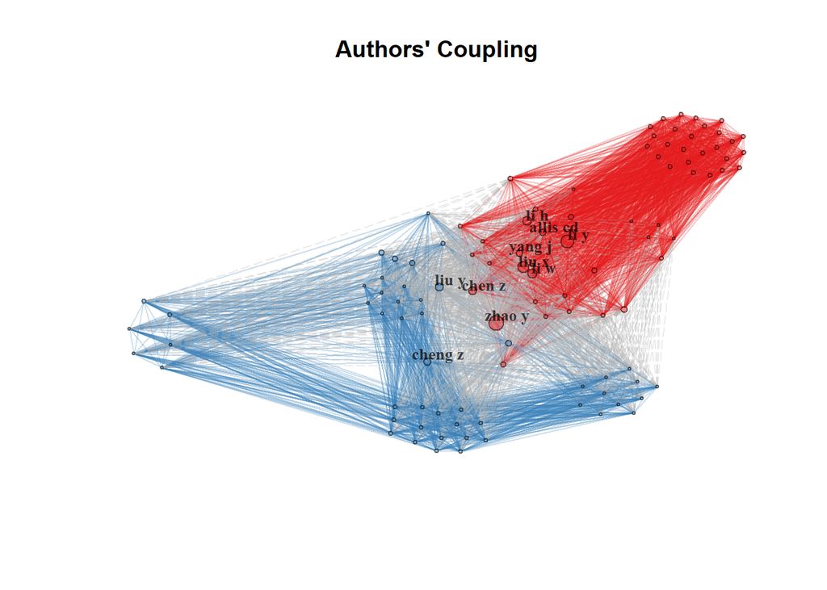

```r
NetMatrix1 <- biblioNetwork(M, analysis = "coupling", network = "authors", sep = ";")

net=networkPlot(NetMatrix1,  normalize = "salton", weighted=NULL, n = 100, Title = "Authors' Coupling", type = "fruchterman", size=5,size.cex=T,remove.multiple=TRUE,labelsize=0.8,label.n=10,label.cex=F)
```

#### c. Co-citação bibliográfica

A co-citação ocorre quando dois artigos são citados em um mesmo terceiro artigo. Podemos calculá-la usando a função “biblioNetwork”:

```r
NetMatrix2 <- biblioNetwork(M, analysis = "co-citation", network = "references", sep = ".  ")
NetMatrix2
```

```
## 32 x 32 sparse Matrix of class "dgCMatrix"
```

```
##    [[ suppressing 32 column names 'SUN H. 2013', 'KESSLER R.C. ', 'RUTHENBURG A.J. 2007' ... ]]
```

```
##
## SUN H. 2013          1 . . . . . . . . . . . . . . . . . . . . . . . . . . . . . . .
## KESSLER R.C.         . 1 . . . . . . . . . . . . . . . . . . . . . . . . . . . . . .
## RUTHENBURG A.J. 2007 . . 1 . . . . . . . . . . . . . . . . . . . . . . . . . . . . .
## TESSARZ P. 2014      . . . 1 . . . . . . . . . . . . . . . . . . . . . . . . . . . .
## WALSH C.T. 2005      . . . . 1 . . . . . . . . . . . . . . . . . . . . . . . . . . .
## MARSHALL R.A. 2016   . . . . . 1 . . . . . . . . . . . . . . . . . . . . . . . . . .
## KEATING S.T. 2015    . . . . . . 1 . . . . . . . . . . . . . . . . . . . . . . . . .
## DERIBE Y.L. 2010     . . . . . . . 1 . . . . . . . . . . . . . . . . . . . . . . . .
## SERVET C. 2010       . . . . . . . . 1 . . . . . . . . . . . . . . . . . . . . . . .
## CHOUDHARY C. 2014    . . . . . . . . . 1 . . . . . . . . . . . . . . . . . . . . . .
## ARAFAT W. 1985       . . . . . . . . . . 1 . . . . . . . . . . . . . . . . . . . . .
## KOUZARIDES T. 2007   . . . . . . . . . . . 2 . . . . . . . . . . . . . . . . . . . .
## BERDASCO M. 2010     . . . . . . . . . . . . 1 . . . . . . . . . . . . . . . . . . .
## ECKBURG P.B. 2005    . . . . . . . . . . . . . 1 . . . . . . . . . . . . . . . . . .
## SIEGEL R.L. 2017     . . . . . . . . . . . . . . 1 . . . . . . . . . . . . . . . . .
## CHEN T. 2014         . . . . . . . . . . . . . . . 1 . . . . . . . . . . . . . . . .
## BRUNER K.M. 2015     . . . . . . . . . . . . . . . . 1 . . . . . . . . . . . . . . .
## ALLFREY V.G. 1964    . . . . . . . . . . . . . . . . . 2 . . . . . . . . . . . . . .
## TAN M. 2011-1        . . . . . . . . . . . . . . . . . . 1 . . . . . . . . . . . . .
## TAN M. 2011-2        . . . . . . . . . . . . . . . . . . . 1 . . . . . . . . . . . .
## AGNIHOTRI G.         . . . . . . . . . . . . . . . . . . . . 1 . . . . . . . . . . .
## TAN M. 2011-3        . . . . . . . . . . . . . . . . . . . . . 2 . . . . . . . . . .
## ROTH S.Y. 2001       . . . . . . . . . . . . . . . . . . . . . . 1 . . . . . . . . .
## ESKELAND R. 2010     . . . . . . . . . . . . . . . . . . . . . . . 1 . . . . . . . .
## STRAHL B.D. 2000     . . . . . . . . . . . . . . . . . . . . . . . . 1 . . . . . . .
## BAEK J.-H. 2015      . . . . . . . . . . . . . . . . . . . . . . . . . 1 . . . . . .
## TAN M. 2011-4        . . . . . . . . . . . . . . . . . . . . . . . . . . 1 . . . . .
## BAO X. 2014          . . . . . . . . . . . . . . . . . . . . . . . . . . . 1 . . . .
## AN W. 2002           . . . . . . . . . . . . . . . . . . . . . . . . . . . . 1 . . .
## SABARI B.R. 2015     . . . . . . . . . . . . . . . . . . . . . . . . . . . . . 1 . .
## BOUSSOUAR F. 2008    . . . . . . . . . . . . . . . . . . . . . . . . . . . . . . 1 .
## ALLIS C.D. 1985      . . . . . . . . . . . . . . . . . . . . . . . . . . . . . . . 1
```

#### d. Colaboração bibliográfica

A rede de colaboração científica é uma rede na qual os pontos são os autores e as linhas que os ligam são coautorias. Podemos calculá-la usando a função “biblioNetwork”:

```r
NetMatrix3 <- biblioNetwork(M, analysis = "collaboration", network = "authors", sep = ";")
```

Para uma rede de colaboração do país seria:

```r
# NetMatrix4 <- biblioNetwork(M, analysis="collaboration", network="countries", sep=";")
```

Obs: Não está funcionando

### 10. Análise descritiva das características gráficas de rede

A função “networkStat” calcula diferentes estatísticas partindo de uma matriz bibliográfica ou objeto igraph, computando o resumo estatístico da rede e os principais índices de centralidade e prestígio das vértices. Por exemplo:

```r
NetMatrix5 <- biblioNetwork(M, analysis = "co-occurrences", network = "keywords", sep = ";")
netstat <- networkStat(NetMatrix)
netstat
```

```
## $graph
## IGRAPH 8f2a8ce UN-- 36 3 --
## + attr: name (v/c), id (v/c)
## + edges from 8f2a8ce (vertex names):
## [1] CHEN W, 2018, MEDICINE. 2018--JU Z, 2017, J MOL GRAPH MODEL. 2017
## [2] SUN H, 2017, SCI REP. 2017  --LI Y, 2017, TRANSCRIPTION. 2017
## [3] XU W, 2017, CELL RES. 2017  --ZHAO D, 2016, CELL RES. 2016
##
## $network
## $network$networkSize
## [1] 36
##
## $network$networkDensity
## [1] 0.004761905
##
## $network$networkTransitivity
## [1] NaN
##
## $network$networkDiameter
## [1] 1
##
## $network$networkDegreeDist
## [1] 1.0000000 0.1666667
##
## $network$networkCentrDegree
## [1] 0.02380952
##
## $network$networkCentrCloseness
## [1] NA
##
## $network$networkCentrEigen
## [1] NA
##
## $network$networkCentrbetweenness
## [1] NA
##
## $network$NetworkAverPathLeng
## [1] 1
##
##
## $vertex
## [1] NA
##
## $stat
## [1] "network"
##
## $type
## [1] "degree"
##
## attr(,"class")
## [1] "bibliometrix_netstat"
```

O resumo estatístico da rede fornecido possui:

```r
names(netstat$network)
```

```
##  [1] "networkSize"             "networkDensity"          "networkTransitivity"     "networkDiameter"
##  [5] "networkDegreeDist"       "networkCentrDegree"      "networkCentrCloseness"   "networkCentrEigen"
##  [9] "networkCentrbetweenness" "NetworkAverPathLeng"
```

Porém não é possível listar os principais índices de centralidade e prestígio das vértices:

```r
names(netstat$vertex)
```

Para resumir os principais resultados da função “networkStat”, usamos “summary”:

```r
summary(netstat, k=10)
```

```
##
##
## Main statistics about the network
##
##  Size                                  36
##  Density                               0.005
##  Transitivity                          NaN
##  Diameter                              1
##  Degree Centralization                 0.024
##  Average path length                   1
##
```

### 11. Visualizando redes bibliográficas

Podemos visualizar ou modeladar graficamente todas as redes bibliográficas utilizando a função “networkPlot”.Seu argumento principal é type, que indica o layout do mapa de rede: circle, kamada-kawai, mds, entre outros.

#### a. Países com Colaboração Científica

Para criar uma rede de países colaboradores e plotar um gráfico, utilizamos os seguintes códigos:

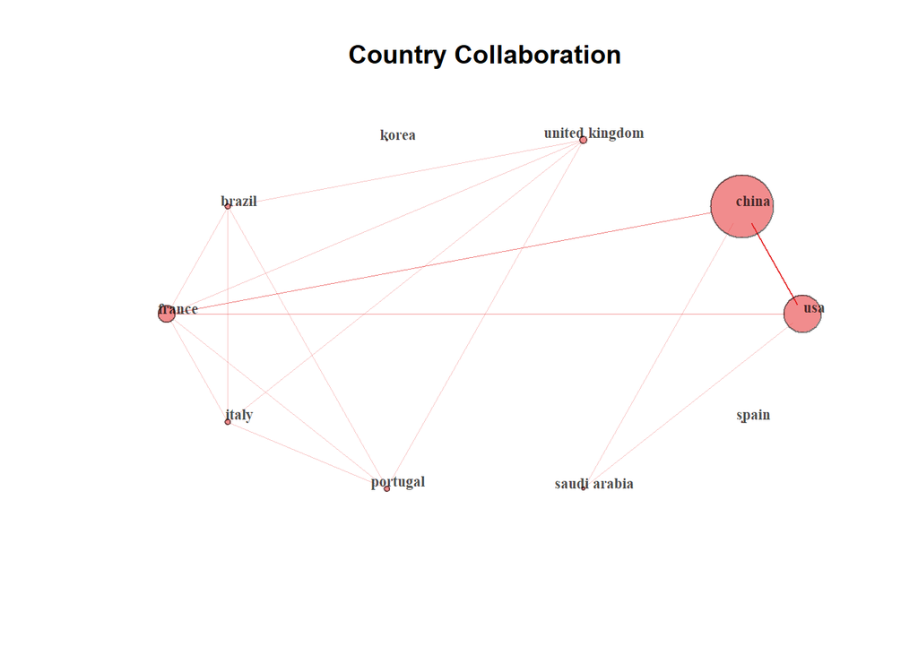

```r
S <- metaTagExtraction(M, Field = "AU_CO", sep = ";")
NetMatrix6 <- biblioNetwork(S, analysis = "collaboration", network = "countries", sep = ";")

net=networkPlot(NetMatrix6, n = dim(NetMatrix6)[1], Title = "Country Collaboration", type = "circle", size=TRUE, remove.multiple=FALSE,labelsize=0.7,cluster="none")
```

#### b. Rede de co-citação

Para criar uma rede de co-citação e plotar um gráfico, usamos:

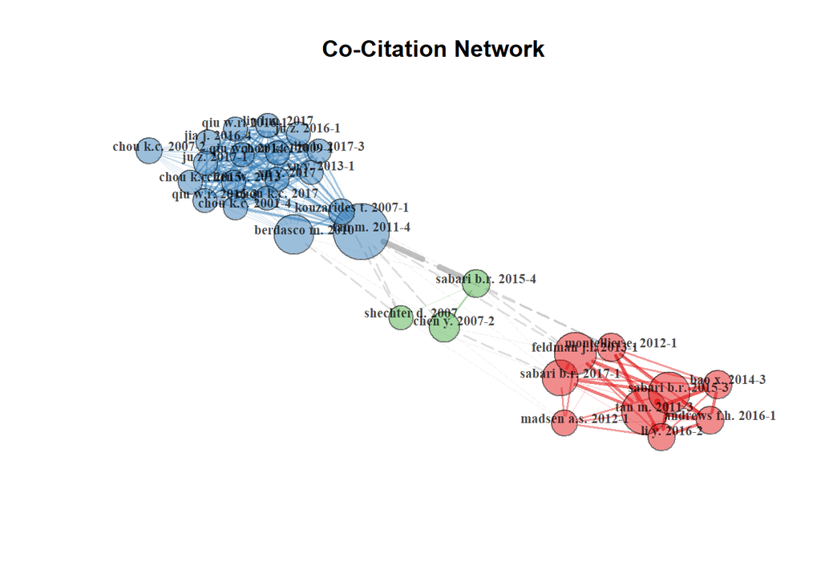

```r
NetMatrix7 <- biblioNetwork(M, analysis = "co-citation", network = "references", sep = ";")

net=networkPlot(NetMatrix7, n = 30, Title = "Co-Citation Network", type = "fruchterman", size=T, remove.multiple=FALSE, labelsize=0.7,edgesize = 5)
```

#### c. Co-ocorrências de palavras-chave

Para criar uma rede de co-ocorrências de palavras-chave e plotar um gráfico seria por:

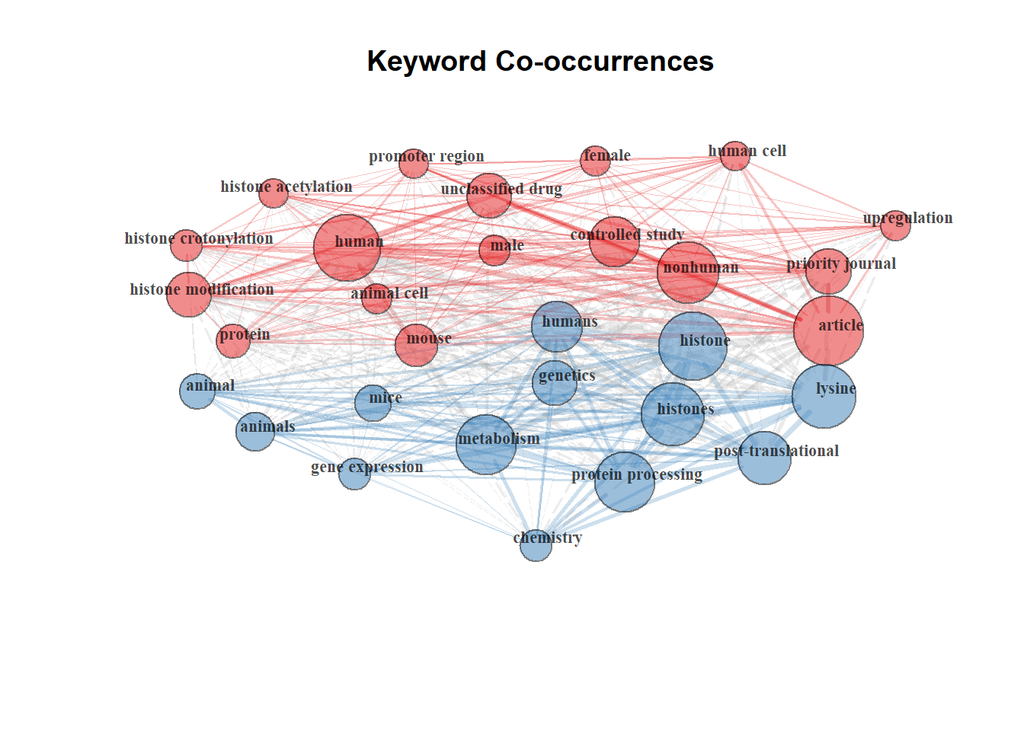

```r
NetMatrix8 <- biblioNetwork(M, analysis = "co-occurrences", network = "keywords", sep = ";")

net=networkPlot(NetMatrix8, normalize="association", weighted=T, n = 30, Title = "Keyword Co-occurrences", type = "fruchterman", size=T,edgesize = 5,labelsize=0.7)
```

### 12. Análise Conjunta: A estrutura conceitual de um campo

O objetivo dessa análise é mapear a estrutura conceitual de um framework usando co-ocorrências em uma coleção bibliográfica. Pode ser feita por Escala Multidimensional (MDS), Análise de Correspondência (AC) ou Análise de Correspondência Múltipla (ACM).

A função “conceptualStructure” extrai termos de títulos e resumos, além de reduzir as palavras flexionadas ou derivadas para as palavras originais. Um exemplo utilizando palavras-chave:

```r
CSK <- conceptualStructure(M,field="ID", method="CA", minDegree=4, k.max=8, stemming=FALSE, labelsize=10, documents=10)
```

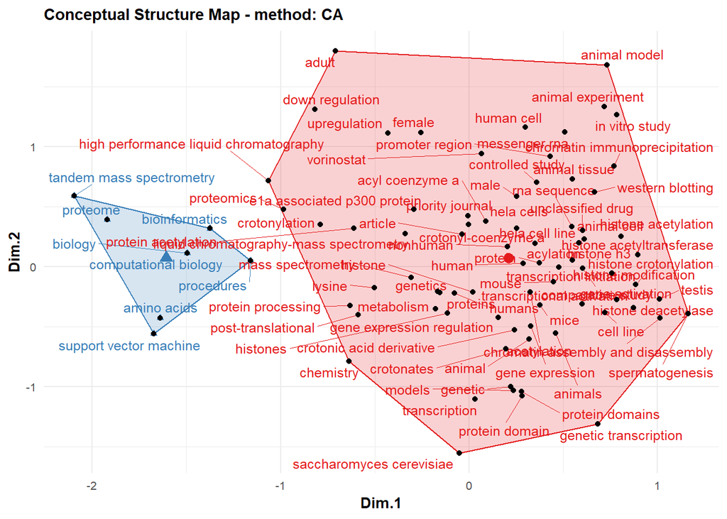

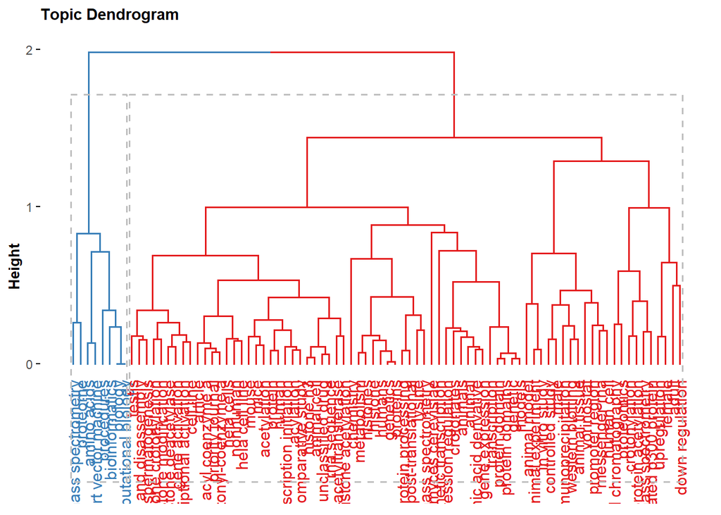

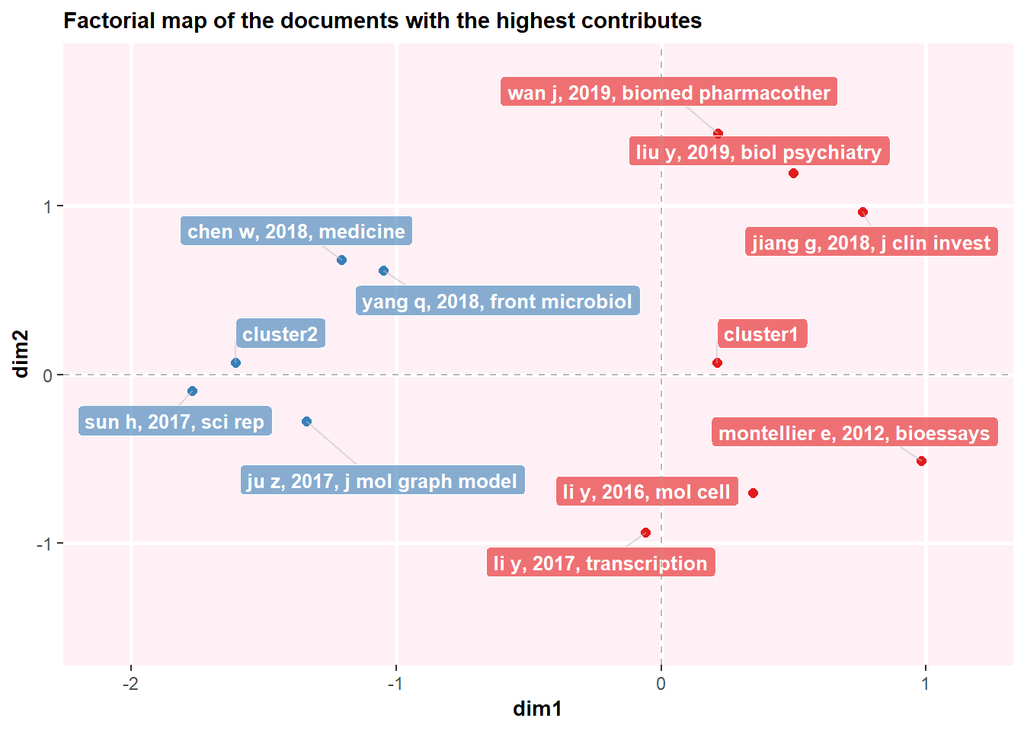

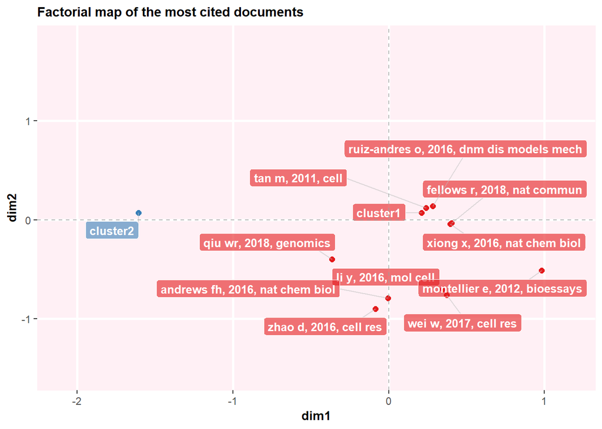

### 13. Rede Histórica de Citação Direta

O mapa historiográfico representa um mapa das citações diretas mais relevantes resultantes de uma coleção bibliográfica em rede cronológica, podendo ser plotada usando “histPlot”:

```r
options(width=130)
histResults <- histNetwork(M, min.citations = 10, sep = ";")
```

```
## Articles analysed   15
```

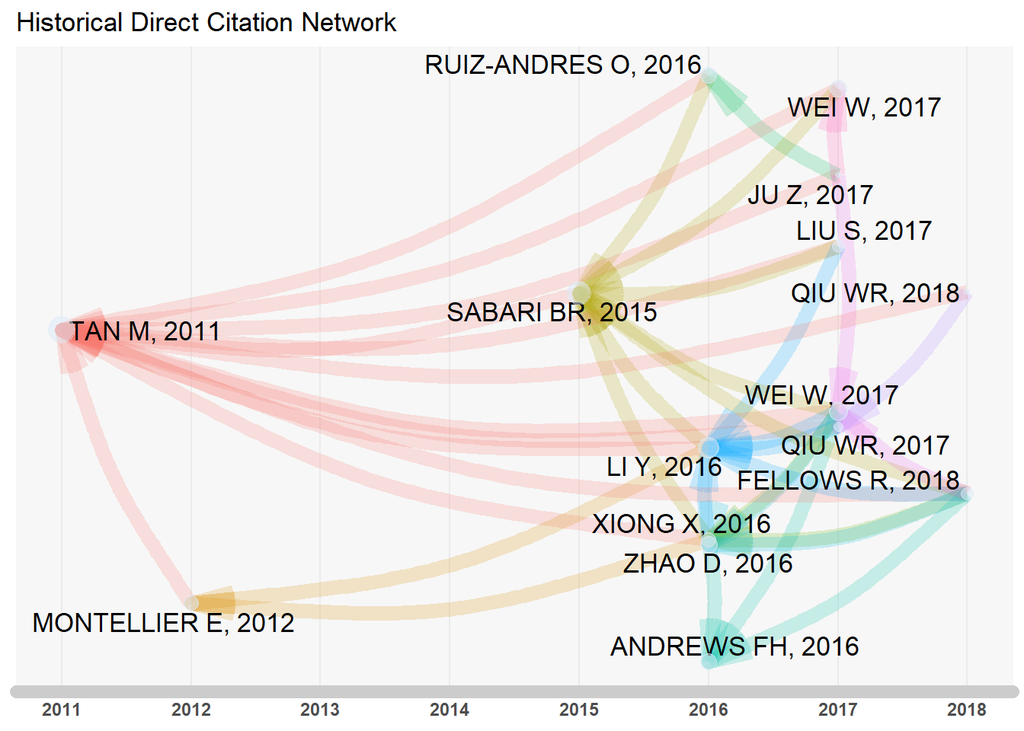

```
##
##  Legend
##
##                                              Paper                           DOI Year LCS GCS
## 2011 - 1                         TAN M, 2011, CELL    10.1016/J.CELL.2011.08.008 2011  28 729
## 2012 - 2             MONTELLIER E, 2012, BIOESSAYS        10.1002/BIES.201100141 2012   5  54
## 2015 - 3               SABARI BR, 2015, MOL CELL-a  10.1016/J.MOLCEL.2015.02.029 2015  21 121
## 2016 - 4              XIONG X, 2016, NAT CHEM BIOL         10.1038/NCHEMBIO.2218 2016   5  32
## 2016 - 5  RUIZ-ANDRES O, 2016, DNM DIS MODELS MECH            10.1242/DMM.024455 2016   7  20
## 2016 - 6           ANDREWS FH, 2016, NAT CHEM BIOL         10.1038/NCHEMBIO.2065 2016   7  49
## 2016 - 7                    ZHAO D, 2016, CELL RES            10.1038/CR.2016.49 2016   8  33
## 2016 - 8                      LI Y, 2016, MOL CELL  10.1016/J.MOLCEL.2016.03.028 2016  15  71
## 2017 - 9            QIU WR, 2017, ARTIF INTELL MED  10.1016/J.ARTMED.2017.02.007 2017   1  10
## 2017 - 10            JU Z, 2017, J MOL GRAPH MODEL    10.1016/J.JMGM.2017.08.020 2017   0  13
## 2017 - 11                    LIU S, 2017, MOL CELL  10.1016/J.MOLCEL.2017.07.011 2017   3  13
## 2017 - 12                    WEI W, 2017, CELL RES            10.1038/CR.2017.68 2017  10  21
## 2017 - 13              WEI W, 2017, J PROTEOME RES 10.1021/ACS.JPROTEOME.7B00012 2017   8  16
## 2018 - 14              FELLOWS R, 2018, NAT COMMUN    10.1038/S41467-017-02651-5 2018   3  26
## 2018 - 15                   QIU WR, 2018, GENOMICS   10.1016/J.YGENO.2017.10.008 2018   0  42
```

```r
net <- histPlot(histResults, n=15, size = 20, labelsize=10, size.cex=TRUE, arrowsize = 0.5, color = TRUE)
```

## Dificuldades encontradas

As principais dificuldades que tive estão relacionadas ao uso do Rmarkdown e GitHub. No Rmarkdown, por exemplo, não consegui diminuir o tamanho da fonte dos gráficos, o que acabou dificultando a visualização de alguns dados pela sobreposição de escritos. Além disso, os códigos referentes a Rede de Países dos Autores (N e Z) no tópico 9.a. e a Rede de Colaboração do País (NetMatrix4) no tópico 9.d. não funcionaram e não soube como consertá-los, mesmo pedindo auxílio a colegas de classe. Quanto ao GitHub, todo o processo para conseguir enviar meus arquivos a um diretório foi complicada. Compreendi melhor buscando tutoriais, que se encontram na bibliografia.

## Bibliografia

#### Rmarkdown:

- Writing documents with R Markdown (https://monashbioinformaticsplatform.github.io/2017-11-16-open-science-training/topics/rmarkdown.html)
- Manual do pacote ‘rmarkdown’ (https://cran.r-project.org/web/packages/rmarkdown/rmarkdown.pdf)

#### Git:

- RStudio e GitHub no dia a dia (https://www.curso-r.com/blog/2017-07-17-rstudio-e-github/)
- Git and GitHub (http://r-pkgs.had.co.nz/git.html)

#### Bibliometrix:

- A brief introduction to bibliometrix (https://cran.r-project.org/web/packages/bibliometrix/vignettes/bibliometrix-vignette.html)
- Manual do pacote ‘bibliometrix’ (https://cran.r-project.org/web/packages/bibliometrix/bibliometrix.pdf)

#### Documento Scopus.bib:

- SCOPUS (http://www.scopus.com)